# Malaria

Shelby Cline

2022-06-09

## Introduction

So Joe dumped some data on us, and there a couple of things I could do with it, but I think I’m just gonna go average length of visit based on diagnosis.

## Methods

I wanted to determine whether or not a patient has a malaria diagnosis would affect the average visit time. To do this, I first created a new column that measured the length of a visit by subtracting the start time from the end time using the as.numeric function, and the difftime function nested in that. I then created a new data frame that measured the average visit time and found the average of both types of diagnosis.

## Results

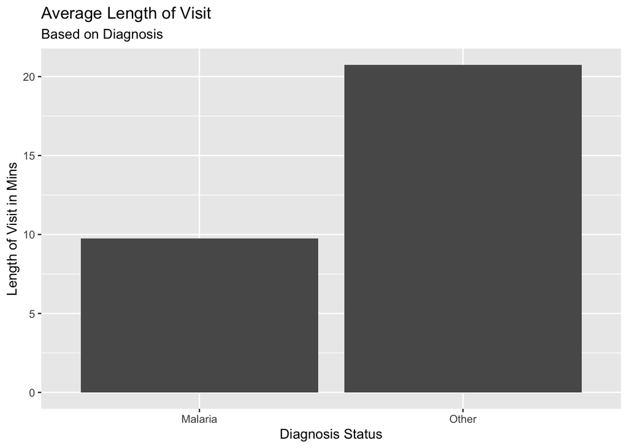

As it turns out, the average visit length for a patient with a “malaria” diagnosis is roughly **9.75 minutes.** The average visit length for a patient with an “other” diagnosis is roughly **20.75 minutes.** I would wager that this difference comes from malaria being super common and having a set procedure, while an “other” diagnosis requires more attention and testing.